# Central Limit Theorem

[figure not shown]

Ok, now that you have learnt some theory, we are going to go through fun simple mini projects to give you a more intuitive understanding of probability and practice some programming on your own. So here's a trick, if you want to improve your coding skills do not copy and paste the code here to your notebook, instead type it out line by line, run each line and see what output is produced, learn through experimentation. Not only is this more enjoyable, it also helps you develop better syntax and programming skills.

Great, so we are going to start off by creating a function that will roll a fair 6 sided dice 10 times and plot the distribution of these outcomes. We will then simulate 100 000 dice rolls. This will help you develop a better understanding of the **Central Limit Theorem**. As always we will also include links to other reading sources that will help you bolster your understanding of the concepts we will be dealing with.

*Time to start!*

```python
import random
roll_dice = [random.randrange(1,7) for _ in range(10)]
```

Great, now we want to count the frequency of each number in our list, convert the list to a dataframe using the pandas library. We want to name the column with the total count of occurencies, *'Frequency'*

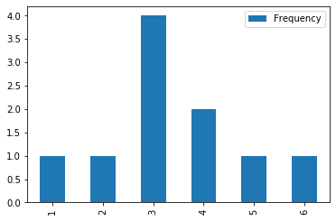

```python
import pandas as pd
from collections import Counter
roll_dice_counter = Counter(roll_dice)
df = pd.DataFrame.from_dict(roll_dice_counter,orient='index', columns=['Frequency'])
#we then sort our index in numerical order and plot our dataframe as barplot
df.sort_index().plot(kind='bar')
```

While we would expect an equal probability of the dice landing in any number between 1 to 6, this is not the case. However, let's see what happens when we roll our dice 100 000 times.

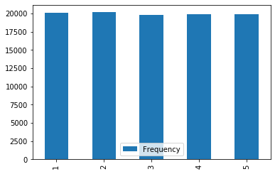

```python
roll_dice_more = [random.randrange(1,6) for _ in range(100000)]
dice_counter = Counter(roll_dice_more)
df_two = pd.DataFrame.from_dict(dice_counter,orient='index', columns=['Frequency'])
#we then sort our index in numerical order and plot our dataframe as barplot
df_two.sort_index().plot(kind='bar')
```

*What?*

## Central Limit Theorem

The Central Limit Theorem is closely related to the law of large numbers. The central limit theorem stats that the sampling distribution of our sample means will approach a normal distribution (resemble a bell curve) as the sample size increases regardless of the shape of the distribution of the population. What this means is that as we roll our dice more and more times, the distribution of the mean will start to resemble a bell curve. The average will lean closer to 3.

https://en.wikipedia.org/wiki/Uniform_distribution_(continuous)

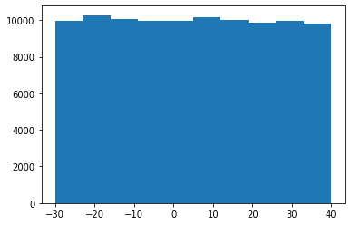

```python
import numpy as np
import random
import matplotlib.pyplot as plt
import scipy.special as sps
s = np.random.uniform(low=-30,high=40,size=100000)
plt.hist(s,)
plt.show()
```

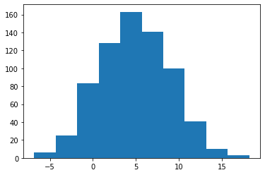

```python
samples = [np.mean(random.choices(s,k=25)) for _ in range(700)]
plt.hist(samples)
plt.show()
```

So what did we do and what does this mean. Well going back to the definition. If we take a large enough sample from the population,the sampling distribution of the mean of a variable regardless of the shape of the distribution of the population, will approximate a normal distribution or in other words it will resemble a bell curve. In this case we continued taking random samples of 25,700 times, and found that the mean of these samples started to resemble a bell curve.

## Why is this important?

Well, as stated in your notes, it is close to impossible to collect the data of the entire population. We can instead gather a subset of our data from the population and use statistics to draw conclusions about the population.

This assumption of the Central Limit Theorem helps us overcome the problem of the data belonging to a population that is not normally distribution. We can quantify the likelihood that our sample will deviate from the population and that the sample will be representative of the population.

We can use the concepts of confidence interval and hypothesis testing to know the likelihood that for example obsvervations likely like within one standard deviation from the population mean.

**How?**

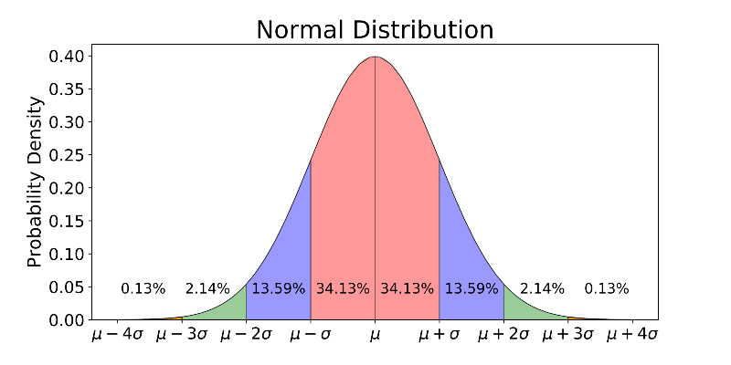

Let's unpack this graph. We call this the **68%**-**95%**-**99.7%** rule. According to this rule 68% of the data is within 1 standard devation of the mean, 95% within 2 standard deviation so the mean and 99.7% within 3 standard deviations of the mean. This rule is typically associated with normal distributions. We can use this rule to easily obtain quick estimates.

Note however, the CLT doesn't talk about the distribution of the data from the sample, it talks about the sample means and sample proportions of many different random samples drawn from the same population.

**CLT assumptions**

This is however all dependent on two key assumptions; Firstly that the value sampled are independent of each other. In other words, is there any reason to think that the data values might affect each other. Secondly, this assumes that the sample size is large enough.We should remember to check whether these assumptions are reasonable. We can try check the reasonableness of these assumptions by asking whether the data came from a randomizatino condition which was not biased and where data sampled was adequately representative of the population.

Here are some interesting videos on CLT:

1. [Inferring population mean from sample mean](https://www.khanacademy.org/math/statistics-probability/sampling-distributions-library/sample-means/v/statistics-sample-vs-population-mean)
2. [Central Limit Theorem](https://www.khanacademy.org/math/statistics-probability/sampling-distributions-library/sample-means/v/central-limit-theorem)
3. [Sampling distribution of the sample mean](https://www.khanacademy.org/math/statistics-probability/sampling-distributions-library/sample-means/v/sampling-distribution-of-the-sample-mean)
4. [Sampling distribution of the sample mean 2](https://www.khanacademy.org/math/statistics-probability/sampling-distributions-library/sample-means/v/sampling-distribution-of-the-sample-mean-2)
5. [Standard error of the mean](https://www.khanacademy.org/math/statistics-probability/sampling-distributions-library/sample-means/v/standard-error-of-the-mean)

Back to your Dashboard